# Episode Jaccard Similarity

Mapping South Park

by Fred

[output not shown]

We present one grouping, Episode by Season, and their similarities.

$$\begin{equation*}
J = \frac{ | A \cap B | }{ |A| + |B| - |A \cap B| }
\end{equation*}$$

Below we map the Jaccard Similarity across episodes of South Park in two different ways. We first map episods with stop words left in then proceed to re run our analysis with stop words removed.

We used a `doc_proportion_max` of 0.05

From the documentation: “maximum proportion of documents which should contain term.”

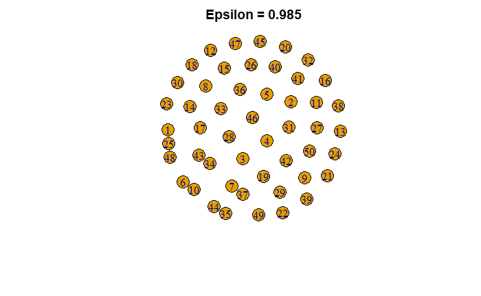

Where $\epsilon = 0.9825$

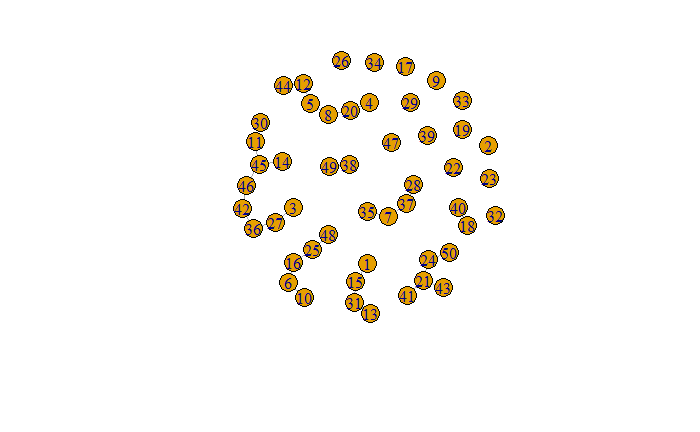

Further investigation needs to be done to determine why these sets of episodes are paired.

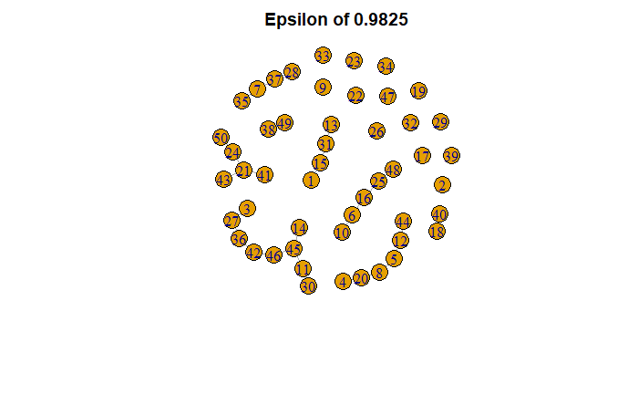

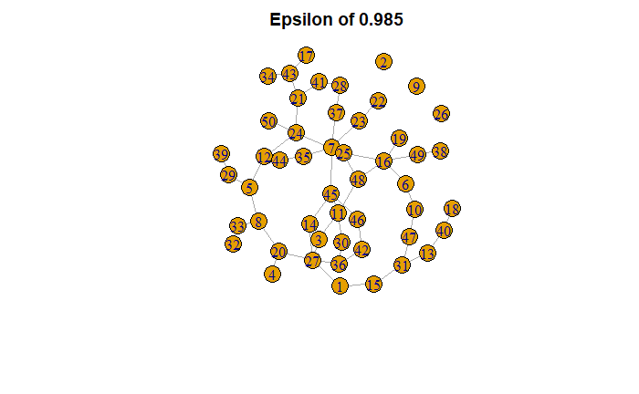

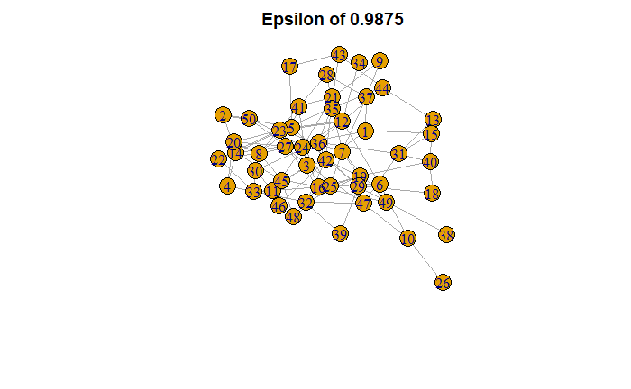

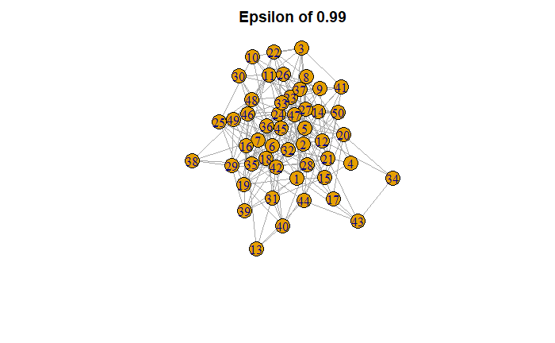

We filtered out words that only occured in one episode, then plotted their tfidf score to find the most important words in common to both episodes.

[output not shown]

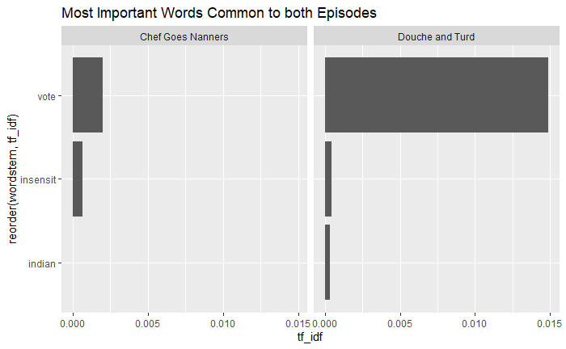

[output not shown]

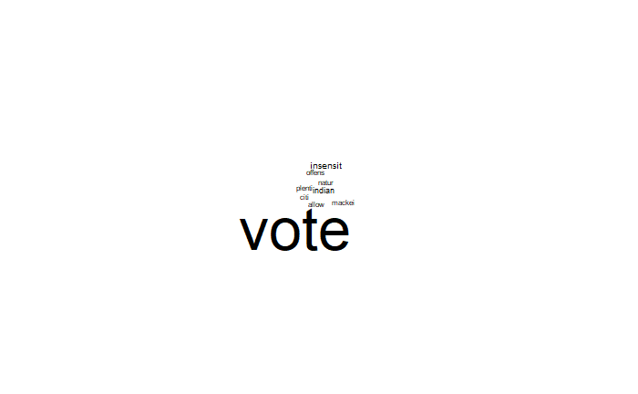